# Assignment 01 Companion Notebook

This notebook contains some examples that show off various properties of linear regression. This notebook is mostly focused on linear regression from a top-down perspective. That is, we are concerned with how does the algorithm behave rather than how it is implemented. As such we will be using a built-in solver for linear regression and treating it essentially as a black box (you will be opening that black box later in the assignment).

## Numpy Practice

While you will not be doing any programming in this assignment, in order to understand the provided examples it helps to have at least a little bit of knowledge of `numpy`. Additionally, we will be using `numpy` extensively in this course. Please use the code block below to play around a bit with `numpy` (assuming you aren't already well-versed in `numpy`'s use').

In order to help you learn how to use `numpy`, you may consider consulting one of these tutorials.

- [Numpy for MATLAB Users](https://docs.scipy.org/doc/numpy/user/numpy-for-matlab-users.html)
- [Numpy Cheatsheet](https://s3.amazonaws.com/assets.datacamp.com/blog_assets/Numpy_Python_Cheat_Sheet.pdf)

```python
# play around with numpy here
import numpy as np
```

## A Toy Linear Regression Problem

The notion of a toy problem is very useful for validating that a machine learning algorithm is working as it is intended to. The basic structure of a toy problem is as follows.

Suppose you are given a learning algorithm designed to estimate some model parameters $\textbf{w}$ from some training data $(\mathbf{X}, \mathbf{y})$.

1. Generate values for the model parameters $\mathbf{w}$ (e.g., set them to some known values or generate them randomly). If you were applying your algorithm to real data, you would of course not know these parameters, but instead estimate them from data. For our toy problem, we'll proceed with values that we generate so we can test our algorithms.
2. Generate some training input data, $\mathbf{X}$, (random numbers work well for this). Generate the training output data, $\mathbf{y}$, by applying the model with parameters $\mathbf{w}$. For example, for a linear regression problem if $\mathbf{w}$ represents the regression coefficients, then we can generate each training label, $y_i$ as $y_i = \mathbf{x_i}^\top \mathbf{w}$.
3. Run your learning algorithms on the synthesized training data $(\mathbf{X}, \mathbf{y})$ to arrive at estimated values of the model parameters, $\hat{\mathbf{w}}$.
4. Compare $\mathbf{w}$ and $\hat{\mathbf{w}}$ as a way of understanding whether your learning algorithm is working.

In the next code block, you'll see an example of a toy regression problem where we set $\mathbf{w} = \begin{bmatrix} 1 \\ 2 \end{bmatrix}$, generate some training data, and then recover $\mathbf{w}$ by applying the linear regression algorithm.

```python
import numpy as np

def linear_regression(X, y):
    w, _, _, _ = np.linalg.lstsq(X, y, rcond=-1)
    return w

n_points = 50
X = np.random.randn(n_points,2)
w_true = np.array([1, 2])
y = X.dot(w_true)
w_estimated = linear_regression(X, y)

w_estimated
```

```
array([1., 2.])
```

### *Notebook Exercise 1*

(a) What should be true about the relationship between `w_true` and `w_estimated` if the algorithm is working properly?

(b) Are there values of `n_points` that would cause `w_true` to be different from `w_estimated'? (this is a bit tricky, so try some corner cases, values at the extremes, and see if you get a different result. If you do, try ot understand why.)

*Solution*

(a) These two vectors should be equal since the inferences of the model should match the true parameters.

(b) `n_points = 1` will give you a value for `w_estimated` that doesn't match `w_true`. This is because them problem is underconstrained (there are more unknowns than equations). Thus, the linear regression method can find multiple solutions that drive the cost to 0 and has no way of knowing which the correct one was.

### Investigating Noise

One thing you might be interested in knowing is how well the algorithm will work when the data doesn't perfectly conform to the hypothesized model (i.e., $y \neq \mathbf{x}^\top \mathbf{w}$).

In the next code block we'll add some noise to the labels and see if the linear regression algorithm can still reconstruct the true parameters $\mathbf{w}$. In particular, we are going to add noise generated from a [Gaussian distribution](https://en.wikipedia.org/wiki/Normal_distribution) with a specified standard deviation. By modifying `noise_standard_deviation`, you can explore how the magnitude of the noise influences the quality of the results (we'll be exploring standard deviation and Gaussians in more detail later in this course). For now you can just think of `noise_standard_deviation` as controlling the magnitude of corruption applied to the training outputs.

Additionally, By modifying `n_points` you can change how many training points are available to the linear regression model for parameter estimation.

```python
n_points = 50
noise_standard_deviation = 2
X = np.random.randn(n_points,2)
w_true = np.array([1, 2])
y = X.dot(w_true) + np.random.randn(n_points,) * noise_standard_deviation
w_estimated = linear_regression(X, y)

w_estimated
```

```
array([1.21351413, 2.18360576])
```

### *Notebook Exercise 2*

(a) Keeping `noise_standard_deviation` constant, characterize qualitatively the relationship between `n_points` and how close `w_estimated` is to `w_true`? Why do you think this is the case (you don't have the formal language to describe this yet, so try to give a conceptual argument)?

(b) Keeping `n_points` constant, characterize qualitatively the relationship between `noise_standard_deviation` and how close `w_estimated` is to `w_true`? Why do you think this is the case (you don't have the formal language to describe this yet, so try to give a conceptual argument)?

*Solution*

(a) as `n_points` gets higher `w_estimated` gets closer to `w_true`. This makes sense intuitively since the random noise added to the training outputs `y` gets averaged out as more training poitns are provided.

(b) as `noise_standard_deviation` gets higher `w_estimated` gets farther from `w_true`. This makes sense intuitively since the random noise added to each to training output is greater and thus has the parameter estimates from linear regression are noisier as well.

### Adding a y-intercept (bias) term

The beautiful thing about linear regression is that we can make it work for non-linear functions quite easily. The easiest way to do this is by augmenting the input data with additional features. In this way, functions that are non-linear in the original input space become linear in the agumented space.

For instance, the function $\mathbf{w}^\top \mathbf{x} + b$ (where $b$ is a scalar or bias term) is non-linear (We know it looks linear but it is actually affine. If you are not convinced, you can test it against the properties of a [linear map](https://en.wikipedia.org/wiki/Linear_map)). On the other hand if we construct the vectors $\mathbf{\tilde{x}} = \begin{bmatrix} \mathbf{x} \\ 1 \end{bmatrix}$ and $\mathbf{\tilde{w}} = \begin{bmatrix} \mathbf{w} \\ b \end{bmatrix}$, then $\mathbf{w}^\top \mathbf{x} + b = \mathbf{\tilde{w}}^\top \mathbf{\tilde{x}}$ where $\mathbf{\tilde{w}}^\top \mathbf{\tilde{x}}$ is now a linear function!

In the code block below, you'll see how this idea can be used to fit a linear regression model to model with a bias term.

```python
b = 3
y = X.dot(w_true) + b
linear_regression(np.hstack((X, np.ones((X.shape[0],1)))), y)
```

```
array([1., 2., 3.])
```

### Handling Other types of Non-linear Functions

Provided you know the form of the non-linear function you are fitting, you can use linear regression to fit arbitrary non-linear functions.

In the code below we will explore an example where the $y_i = w^\top x_i+x_{i,1}^2$. We'll create modified feature vector $\mathbf{\tilde{x}} = \begin{bmatrix} x \\ x^2 \end{bmatrix}$, and apply linear regression to those vectors. You'll see that the linear regression with the additional feature will match much better to the training data (have a lower error) than the one where we don't allow for this new feature.

```
w_estimated [6.28834633]
Sum of squares for original model 233.8487631525443
w_estimated_augmented [3. 1.]
Sum of squares for augmented model 4.599059077438499e-28
```

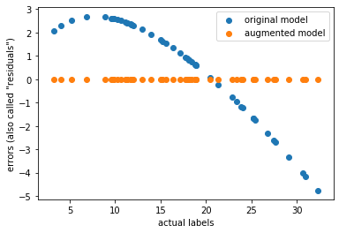

```python
n_points = 50
X = np.random.randn(n_points,1) + 3
w_true = np.array([3])
y = X.dot(w_true) + np.square(X[:,0])
w_estimated = linear_regression(X, y)
original_model_preds = X.dot(w_estimated)
print("w_estimated", w_estimated)
print("Sum of squares for original model", np.sum(np.square(original_model_preds - y)))

X_augmented = np.column_stack((X, np.square(X[:,0])))
w_estimated_augmented = linear_regression(X_augmented, y)
print("w_estimated_augmented", w_estimated_augmented)

augmented_model_preds = X_augmented.dot(w_estimated_augmented)
print("Sum of squares for augmented model", np.sum(np.square(augmented_model_preds - y)))
%matplotlib inline
import matplotlib.pyplot as plt
plt.scatter(y, original_model_preds - y)
plt.scatter(y, augmented_model_preds - y)
plt.xlabel('actual labels')
plt.ylabel('errors (also called "residuals")')
plt.legend(['original model', 'augmented model'])
plt.show()
```

### *Notebook Exercise 3*

(a) Explain the observed differences in the sum of squares error for the two models. Why is the augmented model more accurate?

(b) In the original model, the coefficient estimated for the input feature is much higher than the true value (roughly twice as large). Explain why this occurs and why the augmented model doesn't have this problem?

(c) If you were applying linear regression to a real problem, how might you determine features to add to your model to capture non-linearities? There are many right answers to this, so you should be thinking of this as an open-ended question rather than one with a specific right answer.

*Solution*

(a) The augmented model is much more accurate (has a lower sum of squares) because due to the additional feature it can model the non-linear behavior in the training data.

(b) The original model is forced to artificially inflate the weight placed on the input feature to compensate for not being able to model the non-linear (quadratic behavior). It winds up overestimating the outputs for low input values and underestimating them for high input values. Since the augmented model has the quadratic feature, it can properly assign weight to that feature and keep the weight on the original feature at the appropriate value.

(c) There are lots of ways to do this. Here are three (we know you'll come up with more good ideas):

- See if there are any patterns in the plot of model residuals (e.g., the plot above shows a quadratic pattern in the errors, which might point towards the need to add a quadratic feature).
- Use domain-specific knowledge. For instance, there might be a reason why you expect a particular non-linear behavior to show up (e.g., you are modeling data that is periodic, such as temperature fluctuations over the year, and you know there is some sinusoidal behavior).
- You can use brute force search to try a bunch of different non-linearities and see which ones fit the data the best (there are a lot of machine learning models that work like this).

## Predicting Bikeshare Data (Your First Machine Learning Application!)

The University of California maintains a repository of machine learning datasets. These datasets have been used over the years to benchmark algoirthms in order to faciltate comparisons to previously published work. In this next section of the notebook you will be exploring the [Bikeshare dataset](https://archive.ics.uci.edu/ml/datasets/bike%20sharing%20dataset). The Bikeshare dataset contains daily usage data over a roughly two year period. Along with each record of user counts, there are independent variables that measure various characteristics of the day in question (e.g., whether it was a weekday or a weekend, the air temperature, the wind speed).

Here is what the data looks like (Note: we're using Pandas for this example. We'll be learning some Pandas later in the course, but for now don't worry about it).

```python
import pandas as pd
bikeshare = pd.read_csv('https://raw.githubusercontent.com/kylecho/nd101_p1_neural_network/master/Bike-Sharing-Dataset/day.csv')
bikeshare
```

|  | instant | dteday | season | yr | mnth | holiday | weekday | workingday | weathersit | temp | atemp | hum | windspeed | casual | registered | cnt |
| --- | --- | --- | --- | --- | --- | --- | --- | --- | --- | --- | --- | --- | --- | --- | --- | --- |
| 0 | 1 | 2011-01-01 | 1 | 0 | 1 | 0 | 6 | 0 | 2 | 0.344167 | 0.363625 | 0.805833 | 0.160446 | 331 | 654 | 985 |
| 1 | 2 | 2011-01-02 | 1 | 0 | 1 | 0 | 0 | 0 | 2 | 0.363478 | 0.353739 | 0.696087 | 0.248539 | 131 | 670 | 801 |
| 2 | 3 | 2011-01-03 | 1 | 0 | 1 | 0 | 1 | 1 | 1 | 0.196364 | 0.189405 | 0.437273 | 0.248309 | 120 | 1229 | 1349 |
| 3 | 4 | 2011-01-04 | 1 | 0 | 1 | 0 | 2 | 1 | 1 | 0.200000 | 0.212122 | 0.590435 | 0.160296 | 108 | 1454 | 1562 |
| 4 | 5 | 2011-01-05 | 1 | 0 | 1 | 0 | 3 | 1 | 1 | 0.226957 | 0.229270 | 0.436957 | 0.186900 | 82 | 1518 | 1600 |
| 5 | 6 | 2011-01-06 | 1 | 0 | 1 | 0 | 4 | 1 | 1 | 0.204348 | 0.233209 | 0.518261 | 0.089565 | 88 | 1518 | 1606 |
| 6 | 7 | 2011-01-07 | 1 | 0 | 1 | 0 | 5 | 1 | 2 | 0.196522 | 0.208839 | 0.498696 | 0.168726 | 148 | 1362 | 1510 |
| 7 | 8 | 2011-01-08 | 1 | 0 | 1 | 0 | 6 | 0 | 2 | 0.165000 | 0.162254 | 0.535833 | 0.266804 | 68 | 891 | 959 |
| 8 | 9 | 2011-01-09 | 1 | 0 | 1 | 0 | 0 | 0 | 1 | 0.138333 | 0.116175 | 0.434167 | 0.361950 | 54 | 768 | 822 |
| 9 | 10 | 2011-01-10 | 1 | 0 | 1 | 0 | 1 | 1 | 1 | 0.150833 | 0.150888 | 0.482917 | 0.223267 | 41 | 1280 | 1321 |
| 10 | 11 | 2011-01-11 | 1 | 0 | 1 | 0 | 2 | 1 | 2 | 0.169091 | 0.191464 | 0.686364 | 0.122132 | 43 | 1220 | 1263 |
| 11 | 12 | 2011-01-12 | 1 | 0 | 1 | 0 | 3 | 1 | 1 | 0.172727 | 0.160473 | 0.599545 | 0.304627 | 25 | 1137 | 1162 |
| 12 | 13 | 2011-01-13 | 1 | 0 | 1 | 0 | 4 | 1 | 1 | 0.165000 | 0.150883 | 0.470417 | 0.301000 | 38 | 1368 | 1406 |
| 13 | 14 | 2011-01-14 | 1 | 0 | 1 | 0 | 5 | 1 | 1 | 0.160870 | 0.188413 | 0.537826 | 0.126548 | 54 | 1367 | 1421 |
| 14 | 15 | 2011-01-15 | 1 | 0 | 1 | 0 | 6 | 0 | 2 | 0.233333 | 0.248112 | 0.498750 | 0.157963 | 222 | 1026 | 1248 |
| 15 | 16 | 2011-01-16 | 1 | 0 | 1 | 0 | 0 | 0 | 1 | 0.231667 | 0.234217 | 0.483750 | 0.188433 | 251 | 953 | 1204 |
| 16 | 17 | 2011-01-17 | 1 | 0 | 1 | 1 | 1 | 0 | 2 | 0.175833 | 0.176771 | 0.537500 | 0.194017 | 117 | 883 | 1000 |
| 17 | 18 | 2011-01-18 | 1 | 0 | 1 | 0 | 2 | 1 | 2 | 0.216667 | 0.232333 | 0.861667 | 0.146775 | 9 | 674 | 683 |
| 18 | 19 | 2011-01-19 | 1 | 0 | 1 | 0 | 3 | 1 | 2 | 0.292174 | 0.298422 | 0.741739 | 0.208317 | 78 | 1572 | 1650 |
| 19 | 20 | 2011-01-20 | 1 | 0 | 1 | 0 | 4 | 1 | 2 | 0.261667 | 0.255050 | 0.538333 | 0.195904 | 83 | 1844 | 1927 |
| 20 | 21 | 2011-01-21 | 1 | 0 | 1 | 0 | 5 | 1 | 1 | 0.177500 | 0.157833 | 0.457083 | 0.353242 | 75 | 1468 | 1543 |
| 21 | 22 | 2011-01-22 | 1 | 0 | 1 | 0 | 6 | 0 | 1 | 0.059130 | 0.079070 | 0.400000 | 0.171970 | 93 | 888 | 981 |
| 22 | 23 | 2011-01-23 | 1 | 0 | 1 | 0 | 0 | 0 | 1 | 0.096522 | 0.098839 | 0.436522 | 0.246600 | 150 | 836 | 986 |
| 23 | 24 | 2011-01-24 | 1 | 0 | 1 | 0 | 1 | 1 | 1 | 0.097391 | 0.117930 | 0.491739 | 0.158330 | 86 | 1330 | 1416 |
| 24 | 25 | 2011-01-25 | 1 | 0 | 1 | 0 | 2 | 1 | 2 | 0.223478 | 0.234526 | 0.616957 | 0.129796 | 186 | 1799 | 1985 |
| 25 | 26 | 2011-01-26 | 1 | 0 | 1 | 0 | 3 | 1 | 3 | 0.217500 | 0.203600 | 0.862500 | 0.293850 | 34 | 472 | 506 |
| 26 | 27 | 2011-01-27 | 1 | 0 | 1 | 0 | 4 | 1 | 1 | 0.195000 | 0.219700 | 0.687500 | 0.113837 | 15 | 416 | 431 |
| 27 | 28 | 2011-01-28 | 1 | 0 | 1 | 0 | 5 | 1 | 2 | 0.203478 | 0.223317 | 0.793043 | 0.123300 | 38 | 1129 | 1167 |
| 28 | 29 | 2011-01-29 | 1 | 0 | 1 | 0 | 6 | 0 | 1 | 0.196522 | 0.212126 | 0.651739 | 0.145365 | 123 | 975 | 1098 |
| 29 | 30 | 2011-01-30 | 1 | 0 | 1 | 0 | 0 | 0 | 1 | 0.216522 | 0.250322 | 0.722174 | 0.073983 | 140 | 956 | 1096 |
| ... | ... | ... | ... | ... | ... | ... | ... | ... | ... | ... | ... | ... | ... | ... | ... | ... |
| 701 | 702 | 2012-12-02 | 4 | 1 | 12 | 0 | 0 | 0 | 2 | 0.347500 | 0.359208 | 0.823333 | 0.124379 | 892 | 3757 | 4649 |
| 702 | 703 | 2012-12-03 | 4 | 1 | 12 | 0 | 1 | 1 | 1 | 0.452500 | 0.455796 | 0.767500 | 0.082721 | 555 | 5679 | 6234 |
| 703 | 704 | 2012-12-04 | 4 | 1 | 12 | 0 | 2 | 1 | 1 | 0.475833 | 0.469054 | 0.733750 | 0.174129 | 551 | 6055 | 6606 |
| 704 | 705 | 2012-12-05 | 4 | 1 | 12 | 0 | 3 | 1 | 1 | 0.438333 | 0.428012 | 0.485000 | 0.324021 | 331 | 5398 | 5729 |
| 705 | 706 | 2012-12-06 | 4 | 1 | 12 | 0 | 4 | 1 | 1 | 0.255833 | 0.258204 | 0.508750 | 0.174754 | 340 | 5035 | 5375 |
| 706 | 707 | 2012-12-07 | 4 | 1 | 12 | 0 | 5 | 1 | 2 | 0.320833 | 0.321958 | 0.764167 | 0.130600 | 349 | 4659 | 5008 |
| 707 | 708 | 2012-12-08 | 4 | 1 | 12 | 0 | 6 | 0 | 2 | 0.381667 | 0.389508 | 0.911250 | 0.101379 | 1153 | 4429 | 5582 |
| 708 | 709 | 2012-12-09 | 4 | 1 | 12 | 0 | 0 | 0 | 2 | 0.384167 | 0.390146 | 0.905417 | 0.157975 | 441 | 2787 | 3228 |
| 709 | 710 | 2012-12-10 | 4 | 1 | 12 | 0 | 1 | 1 | 2 | 0.435833 | 0.435575 | 0.925000 | 0.190308 | 329 | 4841 | 5170 |
| 710 | 711 | 2012-12-11 | 4 | 1 | 12 | 0 | 2 | 1 | 2 | 0.353333 | 0.338363 | 0.596667 | 0.296037 | 282 | 5219 | 5501 |
| 711 | 712 | 2012-12-12 | 4 | 1 | 12 | 0 | 3 | 1 | 2 | 0.297500 | 0.297338 | 0.538333 | 0.162937 | 310 | 5009 | 5319 |
| 712 | 713 | 2012-12-13 | 4 | 1 | 12 | 0 | 4 | 1 | 1 | 0.295833 | 0.294188 | 0.485833 | 0.174129 | 425 | 5107 | 5532 |
| 713 | 714 | 2012-12-14 | 4 | 1 | 12 | 0 | 5 | 1 | 1 | 0.281667 | 0.294192 | 0.642917 | 0.131229 | 429 | 5182 | 5611 |
| 714 | 715 | 2012-12-15 | 4 | 1 | 12 | 0 | 6 | 0 | 1 | 0.324167 | 0.338383 | 0.650417 | 0.106350 | 767 | 4280 | 5047 |
| 715 | 716 | 2012-12-16 | 4 | 1 | 12 | 0 | 0 | 0 | 2 | 0.362500 | 0.369938 | 0.838750 | 0.100742 | 538 | 3248 | 3786 |
| 716 | 717 | 2012-12-17 | 4 | 1 | 12 | 0 | 1 | 1 | 2 | 0.393333 | 0.401500 | 0.907083 | 0.098258 | 212 | 4373 | 4585 |
| 717 | 718 | 2012-12-18 | 4 | 1 | 12 | 0 | 2 | 1 | 1 | 0.410833 | 0.409708 | 0.666250 | 0.221404 | 433 | 5124 | 5557 |
| 718 | 719 | 2012-12-19 | 4 | 1 | 12 | 0 | 3 | 1 | 1 | 0.332500 | 0.342162 | 0.625417 | 0.184092 | 333 | 4934 | 5267 |
| 719 | 720 | 2012-12-20 | 4 | 1 | 12 | 0 | 4 | 1 | 2 | 0.330000 | 0.335217 | 0.667917 | 0.132463 | 314 | 3814 | 4128 |
| 720 | 721 | 2012-12-21 | 1 | 1 | 12 | 0 | 5 | 1 | 2 | 0.326667 | 0.301767 | 0.556667 | 0.374383 | 221 | 3402 | 3623 |
| 721 | 722 | 2012-12-22 | 1 | 1 | 12 | 0 | 6 | 0 | 1 | 0.265833 | 0.236113 | 0.441250 | 0.407346 | 205 | 1544 | 1749 |
| 722 | 723 | 2012-12-23 | 1 | 1 | 12 | 0 | 0 | 0 | 1 | 0.245833 | 0.259471 | 0.515417 | 0.133083 | 408 | 1379 | 1787 |
| 723 | 724 | 2012-12-24 | 1 | 1 | 12 | 0 | 1 | 1 | 2 | 0.231304 | 0.258900 | 0.791304 | 0.077230 | 174 | 746 | 920 |
| 724 | 725 | 2012-12-25 | 1 | 1 | 12 | 1 | 2 | 0 | 2 | 0.291304 | 0.294465 | 0.734783 | 0.168726 | 440 | 573 | 1013 |
| 725 | 726 | 2012-12-26 | 1 | 1 | 12 | 0 | 3 | 1 | 3 | 0.243333 | 0.220333 | 0.823333 | 0.316546 | 9 | 432 | 441 |
| 726 | 727 | 2012-12-27 | 1 | 1 | 12 | 0 | 4 | 1 | 2 | 0.254167 | 0.226642 | 0.652917 | 0.350133 | 247 | 1867 | 2114 |
| 727 | 728 | 2012-12-28 | 1 | 1 | 12 | 0 | 5 | 1 | 2 | 0.253333 | 0.255046 | 0.590000 | 0.155471 | 644 | 2451 | 3095 |
| 728 | 729 | 2012-12-29 | 1 | 1 | 12 | 0 | 6 | 0 | 2 | 0.253333 | 0.242400 | 0.752917 | 0.124383 | 159 | 1182 | 1341 |
| 729 | 730 | 2012-12-30 | 1 | 1 | 12 | 0 | 0 | 0 | 1 | 0.255833 | 0.231700 | 0.483333 | 0.350754 | 364 | 1432 | 1796 |
| 730 | 731 | 2012-12-31 | 1 | 1 | 12 | 0 | 1 | 1 | 2 | 0.215833 | 0.223487 | 0.577500 | 0.154846 | 439 | 2290 | 2729 |

731 rows × 16 columns

Next, we'll perform regression with the column `cnt` (number of daily riders) as the output variable and `season`, `yr`, `mnth`, `holiday`, `weekday`, `workingday`, `weathersit`, `temp`, `atemp`, `hum`, `windspeed`, and a constant (bias) term as independent (explanatory variables). Why might we do this you ask? One potential reason would be to predict when to purchase or move bikes to meet anticipated demand.

Before actually performing the regression, examine the hex plots below that show pairwise plots between each independent variable and the dependent variable (we avoided using scatter plots as those don't give a good sense of the density of the data when there are lots of overlapping points).

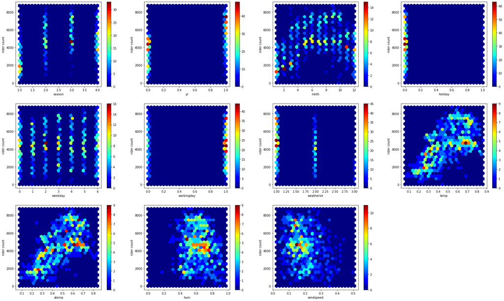

```python
X_bikeshare = bikeshare.drop(columns=['instant', 'dteday', 'cnt', 'registered', 'casual'])
y_bikeshare = bikeshare['cnt']

plt.figure(figsize=(30, 18))
for idx, col in enumerate(X_bikeshare):
    plt.subplot(3, 4, idx+1)
    plt.hexbin(X_bikeshare[col], y_bikeshare, gridsize=25, cmap='jet')
    plt.colorbar()
    plt.xlabel(col)
    plt.ylabel('rider count')

plt.subplots_adjust(wspace=.2)
plt.show()
```

### *Notebook Exercise 4*

(a) Before running the regression, make a prediction as to the sign of each of the coefficients for each of the explanatory variables. That is will the corresponding weight for each of these 11 variables be positive, negative, or close to 0?

*Solution*

(a) Based on what we estimate to be the linear trend in each scatter plot, we make the following predictions.

- season: positive
- yr: positive
- month: weakly positive (there is some downward movement at the end)
- weekday: close to 0
- workingday: positive
- holiday: negative
- weathersit: negative
- temp: positive
- atemp: positive
- hum: close to 0
- windspeed: weakly negative

### *Notebook Exercise 4 (part 2)*

Next, run the actual regression.

(b) Do the results match your predictions? If not, hazard a guess as to why they don't match (you won't necessarily be able to determine this given the information provided).

```python
X_bikeshare['bias'] = 1
list(zip(linear_regression(X_bikeshare, y_bikeshare), X_bikeshare.columns))
```

```
[(509.775198288188, 'season'),
 (2040.703401658302, 'yr'),
 (-38.97956441091838, 'mnth'),
 (-518.9919312460555, 'holiday'),
 (69.06221629898982, 'weekday'),
 (120.35698921300694, 'workingday'),
 (-610.9870081089621, 'weathersit'),
 (2028.916103475132, 'temp'),
 (3573.2742884028607, 'atemp'),
 (-1018.8615712186565, 'hum'),
 (-2557.5691378686074, 'windspeed'),
 (1469.0030645879083, 'bias')]
```

*Solution*

(b) They mostly match. Here are some more observations.

- Windspeed appeared to have a bigger influence (in the negative direction) than we intitially thought.
- `holiday` was hard to estimate mostly due to the visualization of the data as a hexplot (there isn't a lot of data in the `holiday = 1` part of the graph and thus it gets washed out in the plot. Using a different plot like a [box plot](https://en.wikipedia.org/wiki/Box_plot) could be better for this.
- `mnth` was a surprise. This looks like a few outliers at the end of the graph (`mnth` = 12) caused the weight to shift down and become negative.

It's also important to keep in mind that just because a variable is positively correlated with the output, does not imply that the OLS weight is positive. There are situations that arise when the independent variables are correlated with each other when this would not be the case. We'll be diving more into this in the next assignment.